# rgplates

[figure not shown]

[figure not shown]

#### R interface for the *GPlates Web Service* and the *GPlates Application*

## About

Functions to the [GPlates Web Service](https://gws.gplates.org/) and the [GPlates Desktop Application](https://www.gplates.org/) allow users to reconstruct past positions of geographic entities based on user-selected rotation models without leaving the R running environment.

[figure not shown]

The **online reconstruction** (with the [GPlates Web Service](https://gws.gplates.org/)) makes the rotation of static plates, coastlines, and a low number of geographic coordinates available using nothing but an internet connection.

The **offline reconstruction** requires an external installation of the [GPlates Desktop Application](https://www.gplates.org/), but allows the efficient batch rotation of thousands of coordinates, Simple Features ([`sf`](https://cran.r-project.org/package=sf)) and Spatial ([`sp`](https://cran.r-project.org/package=sp)) objects with custom reconstruction trees and partitioning polygons. Examples of such plate tectonic models are accessible via the [chronosphere](https://www.chronosphere.info/).

### Requirements

|  | **Online (GWS)** | **Offline (Desktop App.)** |
| --- | --- | --- |
| Internet connection | ✅ | ❌ |
| [GPlates](https://gws.gplates.org/) installed | ❌ | ✅ |

### Aim

The package was developed to make R-based analyses that require paloecoordinate rotations easier to implement, i.e. for applying a rotation model - but not as a replacement of tools dedidacted to complex paleogeographic reconstruction and model development. For more complex analyses you are more than welcome to check out [gplately](https://gplates.github.io/gplately/) and [pyGPlates](https://www.gplates.org/docs/pygplates/).

## News

- Major update to v0.6 to accommodate changes to the GPlates Web Service (v1.0)
- New plotting functions to make more comprehensive paleogeographic maps (subduction zones, see below)
- Better compatibility of offline methods

## Examples

Here are some quick examples using `rgplates`. See items in the **Tutorials** menu point for detailed explanations of functions.

##### *Paleogeographic maps*

You can reconstruct the positions of the plates at 65 Ma using the [Merdith et al. 2021 model](https://www.sciencedirect.com/science/article/pii/S0012825220305237) and transform them to [Robinson](https://epsg.io/54030) projection using with this chunk of code:

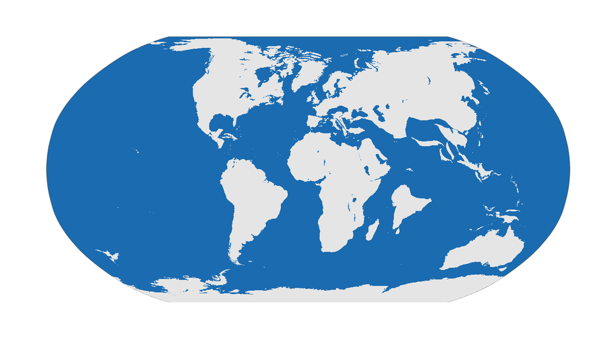

```r
library(rgplates)

# Rotation of plates using the GPlates Web Service
coastlines <- reconstruct("coastlines", age=65, model="MERDITH2021")

# the edge of the map (for mollweide)
edge <- mapedge()

# transform to Robinson
epsg <- "ESRI:54030"
coastsRob <- sf::st_transform(coastlines, crs=epsg)
edgeRob <- sf::st_transform(edge, crs=epsg)

# plot
plot(edgeRob, col="#1A6BB0", border="gray30")
plot(coastsRob, border=NA, col="gray90", add=TRUE)
```

From version 0.6.0, the package supports topological plate boundary export from the [GWS](https://gws.gplates.org/), demonstrated here with the [`CAO2024`](https://doi.org/10.1016/j.gsf.2024.101922) model:

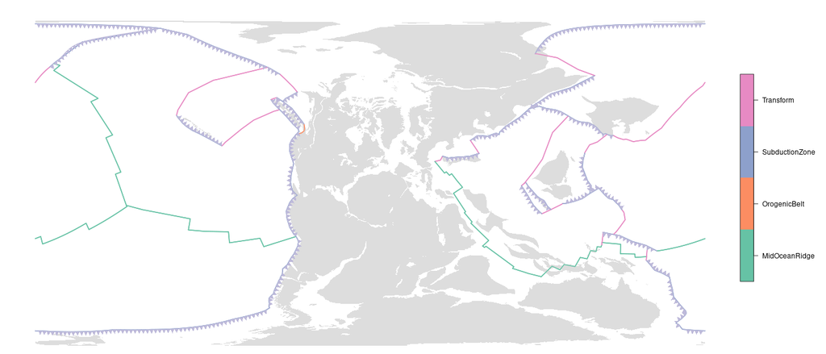

```r
library(rgplates)

# modern coastlines and topological plate boundaries
coasts <- reconstruct("coastlines", age=250, model="CAO2024")
boundaries <- reconstruct("plate_boundaries", age=250, model="CAO2024")

# plot (background wih legend key)
plot(boundaries[, "type"], lwd=2, reset=FALSE,
    main="", key.pos=4)

# coastlines
plot(coasts$geometry, col="#DDDDDD", border=NA, add=TRUE)

# boundaries again
plot(boundaries[, "type"], add=TRUE, lwd=2)

# subduction zones (color from sf)
subcolor <- sf.colors(9, categorical=TRUE)[3]
subductionlines(boundaries, col=subcolor, cex=1.3)
```

##### *Using reconstructions*

The example below demonstrates the contextualization of fossil occurrence records using paleogeographic data products. Here the geographic positions of Kimmeridgian (Late Jurassic) dinosaur fossil collections from the [Paleobiology Database](https://paleobiodb.org/#/) were reconstructed with `rgplates` to match the proxy-corrected HadCM3L climate model results (mean annual air surface temperatures, [Scotese et al. 2021](https://doi.org/10.1016/j.earscirev.2021.103503) after [Valdes et al. 2021](https://doi.org/10.5194/cp-17-1483-2021)), based on the [PALEOMAP model](https://www.earthbyte.org/paleomap-paleoatlas-for-gplates/) (150 Ma). Shading indicates a reconstruction of [possible landmasses](https://doi.org/10.1016/j.earscirev.2020.103463), outlines indicate static plate polygons (also via `rgplates`). Raster and vector data were processed with [`terra`](https://doi.org/10.32614/CRAN.package.terra) and [`sf`](https://doi.org/10.32614/CRAN.package.sf) extensions, dinosaur outlines are from [PhyloPic](https://www.phylopic.org/) via the extension [`rphylopic`](https://doi.org/10.32614/CRAN.package.rphylopic). The code to reproduce the figure is available [here](https://github.com/GPlates/rgplates/raw/devel/pkgdown/assets/kimmeridgian_dinosaurs/code/rgplates_kimmerdigian_dinosaurs.R).

[figure not shown]

## Feature set

Due to the assymmetry of the underlying the dependecies the two main modules of the package (**online**, with GWS - **offline**, with the GPlates Desktop Application), have mismatching feature coverage. The long-term development goal is to make these two as symmetric in capabilities and comparable in performance as possible.

| Feature | **Online (GWS)** | **Offline (Desktop App.)** |
| --- | --- | --- |
| Built-in feature collections | ✅ | ❌ |
| Point reconstruction | ✅ (slow) | ✅ (fast) |
| Vector line/polygon input (`sf`) | ❌ | ✅ |
| Raster input (`terra`) | ✅ | ❌ |
| Paleocoordintate input | ✅ | ❌ |
| Velocity rasters | ✅ | ❌ |

## Notes

#### History

The functions here were originally developed and published as part of the [chronosphere](https://chronosphere.info/r_client/) R package. For better compliance with [UNIX philosophy](https://en.wikipedia.org/wiki/Unix_philosophy) and more efficient distribution/development, the original chronosphere has been broken up to three R packages:

- [`chronosphere`](https://chronosphere.info/r_client/): version-controlled data distribution.
- [`rgplates`](https://gplates.github.io/rgplates/): functions related to tectonic reconstructions.
- [`via`](https://adamkocsis.github.io/via/): Virtual Arrays for efficient organisation of high-dimensional data.

This is a beta version, and like R, comes with absolutely no warranty.